# Tenth Week: Principal Component Analysis and Factor Analysis

PCA Stock, image, …

Shabnam Sheikhha (95105679)

2018-05-20 02:54:17

> با استفاده از داده های OHLCV شرکت های تشکیل دهنده شاخص s&p500 و همچنین داده مربوط به شاخص های اقتصادی به سوالات زیر پاسخ دهید.

# خواندن داده ها

```r
constituents <- read_csv("class_data/constituents.csv")
indexes <- read_csv("class_data/indexes.csv")
files <- list.files("class_data/stock_dfs/")
stocks = list()

for (i in 1:length(files)) {
  temp <- read_csv(paste("class_data/stock_dfs", files[i], sep = "/"))  %>%
    mutate(name = str_remove(files[i], ".csv"))
  stocks[[i]] = temp
}
rm(temp)
stocks <- stocks %>% bind_rows()
```

۱. چه شرکتی رکورددار کسب بیشترین سود در بازه یکساله، دو ساله و پنج ساله می باشد؟ این سوال را برای بخش های مختلف مورد مطالعه قرار دهید و رکورددار را معرفی کنید. (برای این کار به ستون sector داده constituents مراجعه کنید.) برای هر دو قسمت نمودار سود ده شرکت و یا بخش برتر را رسم نمایید.

> پاسخ:

## آماده سازی داده

```r
income.stat <- stocks %>%
  mutate(Date = as.Date(Date)) %>%
  mutate(year = format(Date, "%Y") %>% as.numeric(),
         month = format(Date, "%m") %>% as.numeric(),
         day = format(Date, "%d") %>% as.numeric()) %>%
  mutate(profit = Close - Open)

income.sector.stat <- full_join(income.stat, constituents %>% select(Symbol, Sector),
                                by = c("name" = "Symbol"))

income.sector.stat <- income.sector.stat %>%
  group_by(name, year, month) %>%
  filter(Date == min(Date)) %>%
  mutate(time = 12 * year + month) %>%
  group_by(name) %>%
  mutate(yearOpen = lag(Open, 12),
         twoyearOpen = lag(Open, 24),
         fiveyearOpen = lag(Open, 60)) %>%
  mutate(yearProf = Open - yearOpen,
         twoyearProf = Open - twoyearOpen,
         fiveyearProf = Open - fiveyearOpen)
```

## شرکت رکورددار کسب بیشترین سود در بازه یکساله، دوساله و ۵ساله:

### یکساله:

```r
year.prof <- income.sector.stat %>%
  select(name, yearProf) %>%
  filter(!is.na(yearProf)) %>%
  group_by(name) %>%
  filter(yearProf == max(yearProf)) %>%
  ungroup() %>%
  arrange(desc(yearProf))

year.prof %>% head(1)
```

```
# A tibble: 1 x 2
  name  yearProf
  <chr>    <dbl>
1 BRK.B    1151.
```

### دوساله:

```r
twoyear.prof <- income.sector.stat %>%
  select(name, twoyearProf) %>%
  filter(!is.na(twoyearProf)) %>%
  group_by(name) %>%
  filter(twoyearProf == max(twoyearProf)) %>%
  ungroup() %>%
  arrange(desc(twoyearProf))

twoyear.prof %>% head(1)
```

```
# A tibble: 1 x 2
  name  twoyearProf
  <chr>       <dbl>
1 BRK.B       1815.
```

### ۵ ساله:

```r
fiveyear.prof <- income.sector.stat %>%
  select(name, fiveyearProf) %>%
  filter(!is.na(fiveyearProf)) %>%
  group_by(name) %>%
  filter(fiveyearProf == max(fiveyearProf)) %>%
  ungroup() %>%
  arrange(desc(fiveyearProf))

fiveyear.prof %>% head(1)
```

```
# A tibble: 1 x 2
  name  fiveyearProf
  <chr>        <dbl>
1 BRK.B        2512.
```

## شرکت رکورددار کسب بیشترین سود در بازه یکساله، دوساله و ۵ساله در هر بخش:

### یکساله

```r
income.sector.stat %>%
  select(name, Sector, yearProf) %>%
  filter(!is.na(Sector)) %>%
  filter(!is.na(yearProf)) %>%
  group_by(name) %>%
  filter(yearProf == max(yearProf)) %>%
  ungroup() %>%
  group_by(Sector) %>%
  arrange(desc(yearProf)) %>%
  mutate(rank = rank(-yearProf)) %>%
  filter(rank == 1)
```

```
# A tibble: 11 x 4
# Groups:   Sector [11]
   name  Sector                     yearProf  rank
   <chr> <chr>                         <dbl> <dbl>
 1 BRK.B Financials                   1151.      1
 2 GOOG  Information Technology        421.      1
 3 AMZN  Consumer Discretionary        344.      1
 4 ISRG  Health Care                   262.      1
 5 EQIX  Real Estate                   132.      1
 6 MNST  Consumer Staples              111.      1
 7 CF    Materials                     107.      1
 8 PXD   Energy                        102.      1
 9 AYI   Industrials                    94.3     1
10 DUK   Utilities                      53.6     1
11 T     Telecommunication Services     15.1     1
```

### دوساله

```r
income.sector.stat %>%
  select(name, Sector, twoyearOpen) %>%
  filter(!is.na(Sector)) %>%
  filter(!is.na(twoyearOpen)) %>%
  group_by(name) %>%
  filter(twoyearOpen == max(twoyearOpen)) %>%
  ungroup() %>%
  group_by(Sector) %>%
  arrange(desc(twoyearOpen)) %>%
  mutate(rank = rank(-twoyearOpen)) %>%
  filter(rank == 1)
```

[output not shown]

### ۵ ساله

```r
income.sector.stat %>%
  select(name, Sector, fiveyearProf) %>%
  filter(!is.na(Sector)) %>%
  filter(!is.na(fiveyearProf)) %>%
  group_by(name) %>%
  filter(fiveyearProf == max(fiveyearProf)) %>%
  ungroup() %>%
  group_by(Sector) %>%
  arrange(desc(fiveyearProf)) %>%
  mutate(rank = rank(-fiveyearProf)) %>%
  filter(rank == 1)
```

```
# A tibble: 11 x 4
# Groups:   Sector [11]
   name  Sector                     fiveyearProf  rank
   <chr> <chr>                             <dbl> <dbl>
 1 BRK.B Financials                       2512.      1
 2 GOOG  Information Technology            873.      1
 3 AMZN  Consumer Discretionary            619.      1
 4 REGN  Health Care                       542.      1
 5 EQIX  Real Estate                       287.      1
 6 CF    Materials                         248.      1
 7 AYI   Industrials                       229.      1
 8 PXD   Energy                            205.      1
 9 MNST  Consumer Staples                  188.      1
10 ETR   Utilities                          75.9     1
11 CTL   Telecommunication Services         23.5     1
```

## نمودار ۱۰ شرکت برتر

### یکساله

```r
year.prof %>%
  head(10) %>%
  hchart(type = 'column', hcaes(x = name, y = yearProf %>% round(2)), name = "Profit", color = '#E8AAEF', borderColor = 'black') %>%
  hc_title(text = 'Top 10 Companies',
           align = 'center') %>%
  hc_subtitle(text = 'Highest Profit in A One Year Interval', align = 'center') %>%
  hc_xAxis(title = list(text = "",style = list(color = "white")),tickColor = "white",
           labels = list(style = list(color = "white"))) %>%
  hc_yAxis(title = list(text = "Yearly Profit",style = list(color = "white", fontSize="20px")),tickColor = "white",
           labels = list(style = list(color = "white"))) %>%
  hc_add_theme(hc_theme_merge(hc_theme_538(), hc_theme_darkunica()))
```

[interactive chart not shown]

### دو ساله

```r
twoyear.prof %>%
  head(10) %>%
  hchart(type = 'column', hcaes(x = name, y = twoyearProf %>% round(2)), name = "Profit", color = '#93C5F7', borderColor = 'black') %>%
  hc_title(text = 'Top 10 Companies',
           align = 'center') %>%
  hc_subtitle(text = 'Highest Profit in A One Year Interval', align = 'center') %>%
  hc_xAxis(title = list(text = "",style = list(color = "white")),tickColor = "white",
           labels = list(style = list(color = "white"))) %>%
  hc_yAxis(title = list(text = "Two Year Profit",style = list(color = "white", fontSize="20px")),tickColor = "white",
           labels = list(style = list(color = "white"))) %>%
  hc_add_theme(hc_theme_merge(hc_theme_538(), hc_theme_darkunica()))
```

[interactive chart not shown]

### ۵ ساله

```r
fiveyear.prof %>%
  head(10) %>%
  hchart(type = 'column', hcaes(x = name, y = fiveyearProf %>% round(2)), name = "Profit", color = '#F6FF9F', borderColor = 'black') %>%
  hc_title(text = 'Top 10 Companies',
           align = 'center') %>%
  hc_subtitle(text = 'Highest Profit in A One Year Interval', align = 'center') %>%
  hc_xAxis(title = list(text = "",style = list(color = "white")),tickColor = "white",
           labels = list(style = list(color = "white"))) %>%
  hc_yAxis(title = list(text = "Five Year Profit",style = list(color = "white",
                                                            fontSize="20px")),tickColor = "white",
           labels = list(style = list(color = "white"))) %>%
  hc_add_theme(hc_theme_merge(hc_theme_538(), hc_theme_darkunica()))
```

[interactive chart not shown]

۲. یک اعتقاد خرافی می گوید خرید سهام در روز سیزدهم ماه زیان آور است. این گزاره را مورد ارزیابی قرار دهید.

> پاسخ:

میخواهیم تست کنیم که آیا میانگین سود شرکت ها در روز سیزدهم ماه، کمتر از صفر است یا نه. در واقع فرض صفر این است که میانگین سود شرکت ها در روز سیزدهم ماه کمتر از صفر است، و فرض دیگر این است که بیشتر یا مساوی صفر است.

برای اینکه بفهمیم چه آزمون فرضی را باید استفاده کنیم، نمودار سود در روز سیزدهم را میکشیم تا تخمینی از توزیعشان داشته باشیم:

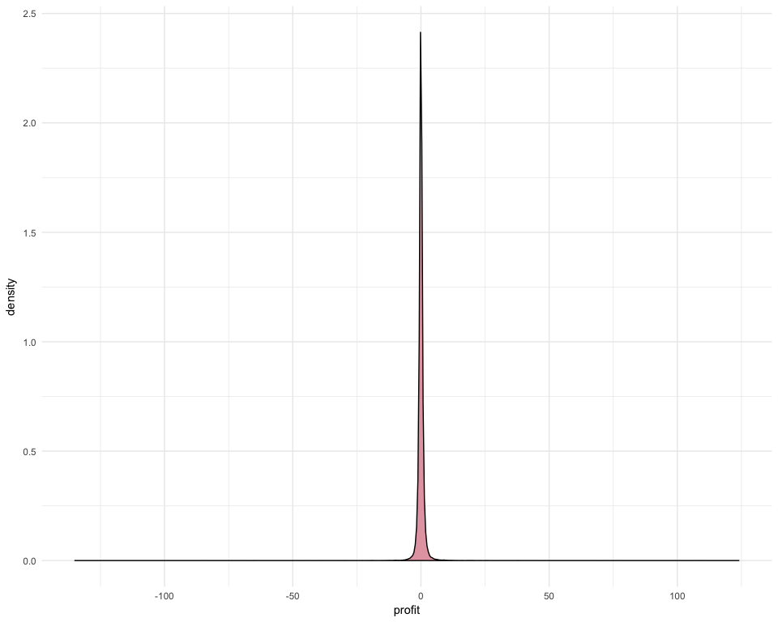

```r
thirteenth <- income.stat %>% filter(day == 13)



## test for normality

ggplot(thirteenth) +
  geom_density(aes(x = profit), fill = "#E5A5B0", color = 'black') +
  theme_minimal()
```

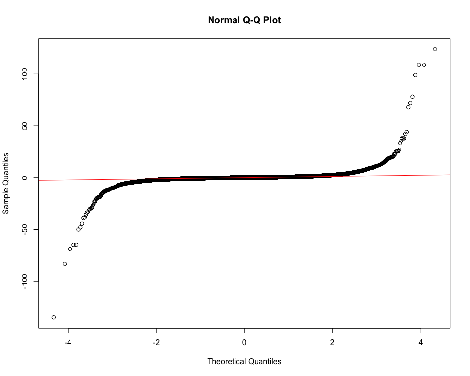

```r
qqnorm(thirteenth$profit)
qqline(thirteenth$profit, col = 2)
```

چون قله ی داده ها خیلی تیز است، استفاده از t.test که مخصوص داده های نرمال است خیلی مناسب به نظر نمیرسد. همچنین در دو سر نمودار بالا، داده ها خیلی از خط نرمال دور هستند.

از آزمون فرض غیر پارامتری wilcoxon استفاده میکنیم.

```r
wilcox.test(thirteenth$profit, alternative = "greater")
```

```
    Wilcoxon signed rank test with continuity correction

data:  thirteenth$profit
V = 1042300000, p-value = 0.4728
alternative hypothesis: true location is greater than 0
```

با توجه به پی-مقدار به دست آمده نمیتوان این فرض خرافاتی را رد کرد.

۳. رکورد بیشترین گردش مالی در تاریخ بورس برای چه روزی بوده است و چرا!!!

> پاسخ:

```r
income.stat %>%
  group_by(Date) %>%
  summarise(trade = sum(Volume * (High - Low))) %>%
  arrange(desc(trade)) %>% head(1)
```

```
# A tibble: 1 x 2
  Date              trade
  <date>            <dbl>
1 2008-10-10 56457067882.
```

بیشترین گردش مالی در تاریخ ۱۰ اکتبر ۲۰۰۸ رخ داده است که همان تاریخ بحران جهانی اقتصادی ۲۰۰۸ است.

برای اطلاعات بیشتر به [اینجا](https://www.money-zine.com/investing/stocks/stock-market-crash-of-2008/) مراجعه کنید

۴. شاخص AAPL که نماد شرکت اپل است را در نظر بگیرید. با استفاده از رگرسیون خطی یک پیش کننده قیمت شروع (open price) بر اساس k روز قبل بسازید. بهترین انتخاب برای k چه مقداری است؟ دقت پیش بینی شما چقدر است؟

> پاسخ:

برای این سوال k را از ۲ تا ۲۰ در نظر گرفته ایم. بدین صورت که در هر مرحله ستون open از دیتافریم apple را به دسته های k+1 تایی تقسیم کرده ایم و در ماتریسی قرار داده ایم. در هر سطر از این ماتریس، predictor ها ستون های 1 تا k هستند و response ستون k + 1 است. در نهایت روی این ماتریس با استفاده از h2o رگرشن میزنیم

```r
Apple <- income.stat %>% filter(name == "AAPL")
library(h2o)
h2o.init()
```

[output not shown]

```r
mses <- c()
for(k in 2:20){
  temp <- Apple$Open %>%
          matrix(ncol = k + 1, byrow = TRUE) %>%
          as.data.frame()
  happle = as.h2o(temp)
  hglm = h2o.glm(y = paste0("V", k + 1),
                 training_frame = happle)
  mses[k] = h2o.mse(hglm)
}
```

کمترین مقدار خطا:

```r
mses.df <- mses %>% as.data.frame() %>% mutate(k = row_number())
colnames(mses.df) <- c("MSE", "k")
mses.df %>%  filter(MSE == min(MSE, na.rm = T))
```

```
       MSE  k
1 95.21148 12
```

۵. بر روی داده های قیمت شروع شرکت ها الگوریتم pca را اعمال کنید. نمودار تجمعی درصد واریانس بیان شده در مولفه ها را رسم کنید. سه مولفه اول چند درصد از واریانس را تبیین می کند؟

> پاسخ:

برای اینکه تعداد زیادی از داده ها از دست نرود، تنها ستون هایی را حذف میکنیم که تعداد na های آنها زیاد باشد.

```r
open.stat <- income.stat %>%
  select(Date, Open, name) %>%
  mutate(Open = as.numeric(Open)) %>%
  spread(name, Open) %>%
  select_if(function(col) sum(is.na(col)) < 500) %>%
  na.omit(center = T)
```

اعمال کردن pca:

```r
pca.open <- prcomp(open.stat %>% select(-Date), center=T, scale.=T)
```

به دست آوردن واریانس ها

```r
sdevs <- pca.open$sdev^2 %>%
  as.data.frame()
names(sdevs) <- c("variance")
sdevs <- sdevs %>%
  arrange(desc(variance)) %>%
  mutate(perc = variance / sum(variance)) %>%
  mutate(perc_ac = cumsum(perc)) %>%
  mutate(pc = rank(-perc))
```

نمودار تجمعی درصد واریانس بیان شده

```r
sdevs %>%
  head(20) %>%
  hchart(type = "spline" ,
         hcaes(x = pc , y = perc_ac),
         color = 'orange', name = "Cumulative Sum of % of Variance Explained") %>%
  hc_add_series(sdevs %>% head(20), "column",
                hcaes(x = pc, y = perc),
                name = "% of Variance Explained",
                color = '#D43A53', borderColor = 'black') %>%
  hc_title(text = 'PCA Analysis',
           align = 'center') %>%
  hc_subtitle(text = 'Top 20 Components', align = 'center') %>%
  hc_xAxis(title = list(text = '#PCA Components')) %>%
  hc_yAxis(title = list(text = 'Sum of Variance')) %>%
  hc_add_theme(hc_theme_merge(hc_theme_538(), hc_theme_darkunica()))
```

[interactive chart not shown]

سه مولفه اول چند درصد از واریانس را تبیین می کند؟

```r
sdevs %>% filter(pc == 3) %>% select(pc, perc_ac)
```

```
  pc   perc_ac
1  3 0.7584026
```

۶. برای هر نماد اطلاعات بخش مربوطه را از داده constituents استخراج نمایید. برای هر بخش میانگین روزانه قیمت شروع شرکت های آن را محاسبه کنید. سپس با استفاده از میانگین به دست آمده داده ایی با چند ستون که هر ستون یک بخش و هر سطر یک روز هست بسازید. داده مربوط را با داده شاخص های اقتصادی ادغام کنید. بر روی این داده pca بزنید و نمودار biplot آن را تفسیر کنید.

> پاسخ:

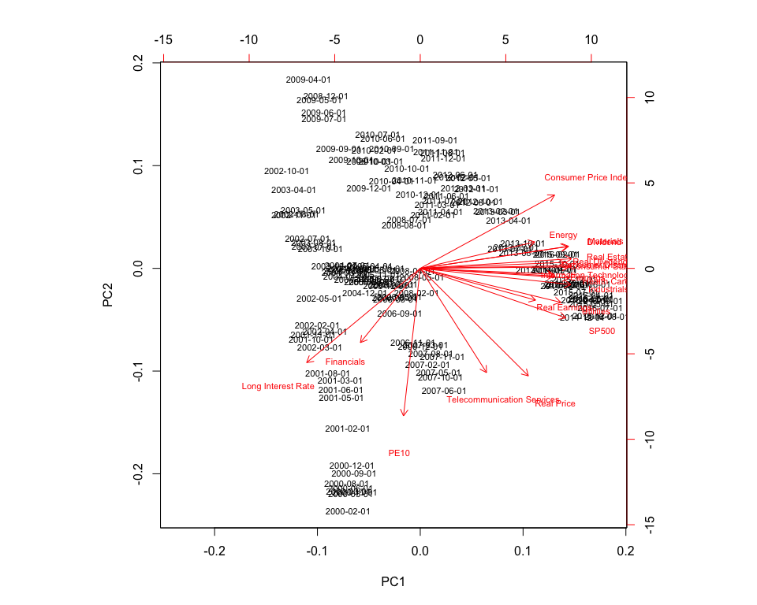

```r
sector.stat <- left_join(income.stat, constituents %>% select(Symbol, Sector),
                                               by = c("name" = "Symbol")) %>%
  select(Sector, name, Open, Date) %>%
  mutate(Data = as.Date(Date)) %>%
  group_by(Sector, Date) %>%
  dplyr::summarise(meanOpen = mean(Open, na.rm = T)) %>%
  drop_na() %>%
  spread(Sector, meanOpen) %>%
  drop_na()

sector.index.stat <- full_join(sector.stat, indexes %>% mutate(Date = as.Date(Date))) %>%
  drop_na()
rownames(sector.index.stat) = sector.index.stat$Date
pca.sector <- prcomp(sector.index.stat %>% select(-Date), center=T, scale. = T)
biplot(pca.sector, cex = 0.7)
```

همبستگی (correlation) بین متغیرها با کسینوس زاویه بین بردارهای متناظرشان مرتبط است. یعنی هرچه زاویه ی بین بردار ها نزدیک تر به صفر باشد correlation متغیر ها بالاتر، هرچه نزدیک در به ۹۰ درجه باشد یعنی correlation ندارند و هر چه نزدیک تر به ۱۸۰ درجه باشد (جهت مخالف) یعنی همبستگی منفی دارند.

برای مثال در اینجا Consumer Price Index با Long Interest Rate رابطه ی کاملا برعکس دارند، در حالی که این دو با Real Price رابطه ندارند اصلا. البته این اطلاعات به دست آمده از روی نمودار نسبی است و نمیتوان کاملا دقیق و با اطمینان صددرصد این گزاره ها را بیان کرد.

همچنین میتوان همجهت بودن بردارها را اینگونه تلقی کرد که اینها در رابطه با توضیح داده ها معنی یکسانی دارند و مشابه با همدیگر هستند.

همچنین داده های مشکی، که نشاندهنده ی روزها (سطرهای دیتافریم) هستند هر جا نزدیک به هم باشند یعنی عملکرد آن روز ها بر اساس PCA اعمال شده شبیه است.

همچنین با تصویر کردن داده ها در جهت محور ها میتوان فهمید که کدام مولفه واریانس بیشتری را پوشش میدهد. اگر داده ها را روی محور PC1 تصویر کنیم، نسبت به تصویر کردن آنها روی PC2 واریانس بیشتری دارند.

۷. روی همه اطلاعات (OHLCV) سهام اپل الگوریتم PCA را اعمال کنید. سپس از مولفه اول برای پیش بینی قیمت شروع سهام در روز آینده استفاده کنید. به سوالات سوال ۴ پاسخ دهید. آیا استفاده از مولفه اول نتیجه بهتری نسبت به داده open price برای پیش بینی قیمت دارد؟

> پاسخ:

مانند سوال ۴، داده را به ماتریس تبدیل میکنیم با این تفاوت که مقدار open را از داخل داده ی سوال ۴ به دست می آوریم

```r
Apple.pca <- prcomp(Apple %>% select(Open, Close, High, Low, Volume))$x
Apple.info <- cbind(Apple.pca, Apple %>% select(Open, Close, High, Low, Volume))
mses.pca = c()

for (k in 2:20) {
  Apple.info$Open %>%
    matrix(ncol = k + 1, byrow = TRUE) %>% as.data.frame() -> Opens
  Apple.info$PC1 %>%
    matrix(ncol = k + 1, byrow = TRUE) %>% as.data.frame() -> PC1s
  colnames(Opens) = c(paste("V", 1:k), "Next Day Open")
  colnames(PC1s) = c(paste("V", 1:k), "Next Day Open")
  PC1s$`Next Day Open` = Opens$`Next Day Open`
  hApple = as.h2o(PC1s)
  hglm = h2o.glm(y = "Next Day Open", training_frame = hApple)
  mses.pca[k] = h2o.mse(hglm)
}
```

کمینه مقدار MSE به ازای پیشبینی با PCA را به دست می آوریم:

```r
mses.pca.df <- mses.pca %>% as.data.frame() %>% mutate(k = row_number())
colnames(mses.pca.df) <- c("PCA MSE", "k")
mses.pca.df %>% filter(`PCA MSE` == min(`PCA MSE`, na.rm = T))
```

```
   PCA MSE  k
1 28711.56 14
```

مقایسه ی پیشبینی سوال ۷ و سوال ۴:

```r
mse.comp <- full_join(mses.pca.df, mses.df, by = c('k')) %>%
  gather(key = "Model", value = "Error", c(1, 3)) %>% drop_na()
mse.comp %>%
  hchart(type = 'column', hcaes(x = k, y = Error, group = Model)) %>%
  hc_xAxis(title = list(text = "K",
                        style = list(color = "black", fontSize = '18px'))) %>%
  hc_yAxis(title = list(text = "Mean Squared Error",
                        style = list(color = "black", fontSize="18px"))) %>%
  hc_legend(align = 'right') %>%
  hc_add_theme(hc_theme_merge(hc_theme_538(colors = c("#0D44B2", "#B20D65"))))
```

[interactive chart not shown]

همانطور که واضح است، PCA به مراتب بدتر عمل کرده است.

۸. نمودار سود نسبی شاخص s&p500 را رسم کنید. آیا توزیع سود نرمال است؟(از داده indexes استفاده کنید.) با استفاده از ده مولفه اول سوال پنج آیا می توانید سود و ضرر شاخص s&p500 را برای روز آينده پیش بینی کنید؟ از یک مدل رگرسیون لاجستیک استفاده کنید. درصد خطای پیش بینی را به دست آورید.

> پاسخ:

ابتدا سود نسبی شاخص مورد نظر را بدین صورت بدست می آوریم:

```r
sp500.prof <- indexes %>%
  mutate(rel.prof = (SP500 - lag(SP500)) / lag(SP500)) %>%
  mutate(state = ifelse(rel.prof > 0, 1, 0))
```

حال برای بررسی نرمال بودن دو نمودار زیر را رسم میکنیم:

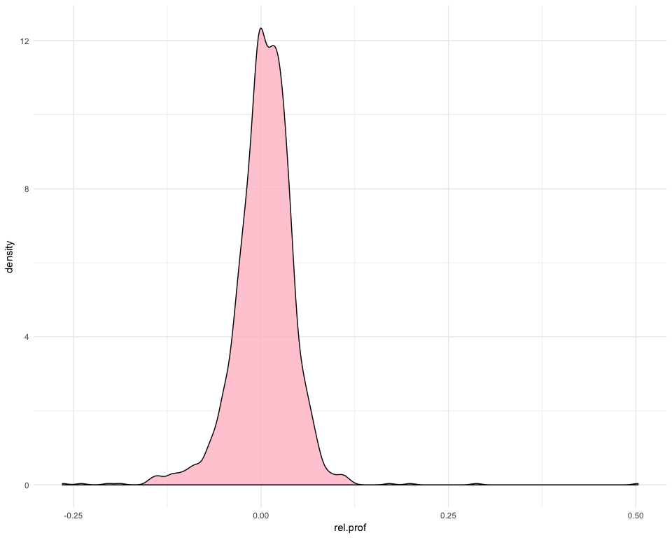

```r
ggplot(sp500.prof) +
  geom_density(aes(x = rel.prof), fill = 'pink', color = 'black', alpha = 0.8) +
  theme_minimal()
```

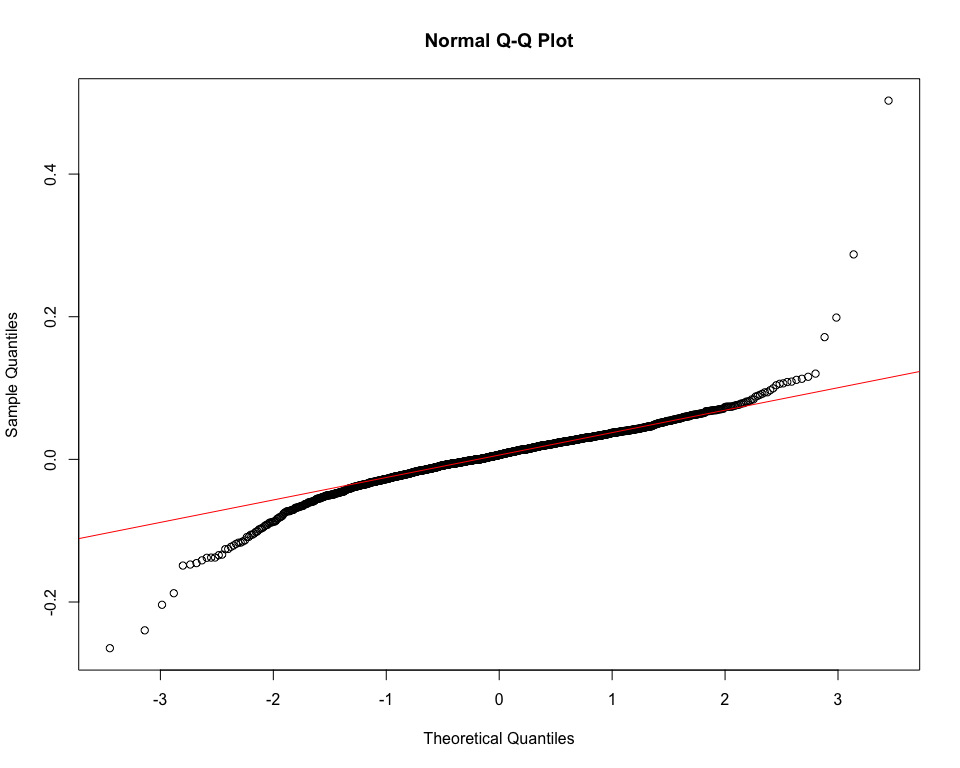

```r
qqnorm(sp500.prof$rel.prof)
qqline(sp500.prof$rel.prof, col = 2)
```

حال داده ی pca سوال ۵ را در نظر میگیریم. ۱۰ مولفه اول آن را به ستون تاریخ داده ی استفاده شده برای ساختن آن pca وصل میکنیم. (با استفاده از `cbind`). این داده را با داده ی ساخته شده در بالا `inner_join` میکنیم.

```r
sp500.pca <- cbind(pca.open$x %>% as.data.frame() %>% dplyr::select(PC1:PC10),
                   open.stat %>% dplyr::select(Date))
train.sp500 <- inner_join(sp500.pca, sp500.prof, by = "Date")
```

حال با استفاده از h2o یک مدل رگرسیون لاجیستیک اعمال میکنیم:

```r
hsp500 <- as.h2o(train.sp500)
hglm.sp500 = h2o.glm(y = "state", training_frame = hsp500, family = "binomial", nfolds = 5)
summary(hglm.sp500)
```

```
Model Details:
==============

H2OBinomialModel: glm
Model Key:  GLM_model_R_1526665132148_536
GLM Model: summary
    family  link                               regularization
1 binomial logit Elastic Net (alpha = 0.5, lambda = 0.06722 )
  number_of_predictors_total number_of_active_predictors
1                         21                           2
  number_of_iterations training_frame
1                    4    train.sp500

H2OBinomialMetrics: glm
** Reported on training data. **

MSE:  0.07913992
RMSE:  0.2813182
LogLoss:  0.2924413
Mean Per-Class Error:  0
AUC:  1
Gini:  1
R^2:  0.6511249
Residual Deviance:  67.26149
AIC:  73.26149

Confusion Matrix (vertical: actual; across: predicted) for F1-optimal threshold:
        0  1    Error    Rate
0      40  0 0.000000   =0/40
1       0 75 0.000000   =0/75
Totals 40 75 0.000000  =0/115

Maximum Metrics: Maximum metrics at their respective thresholds
                        metric threshold    value idx
1                       max f1  0.603307 1.000000  74
2                       max f2  0.603307 1.000000  74
3                 max f0point5  0.603307 1.000000  74
4                 max accuracy  0.603307 1.000000  74
5                max precision  0.998415 1.000000   0
6                   max recall  0.603307 1.000000  74
```

[output cut: 83 more lines]

```
     names coefficients sign
1 rel.prof     1.903834  POS
2     PC10     0.005230  NEG
3      PC1     0.000000  POS
4      PC2     0.000000  POS
5      PC3     0.000000  POS

---
                  names coefficients sign
16 Consumer Price Index     0.000000  POS
17   Long Interest Rate     0.000000  POS
18           Real Price     0.000000  POS
19        Real Dividend     0.000000  POS
20        Real Earnings     0.000000  POS
21                 PE10     0.000000  POS
```

۹. عکسی که در ابتدای متن آمده را در نظر بگیرید. با استفاده از pca عکس را فشرده کنید. سپس نمودار حجم عکس فشرده بر حسب تعداد مولفه اصلی را رسم کنید. بهترین انتخاب برای انتخاب تعداد مولفه ها در جهت فشرده سازی چه عددی است؟

> پاسخ:

ابتدا عکس را با pca فشرده میکنیم.

```r
library("EBImage")
pic = flip(readImage("stock.jpg"))
red.weigth   = imageData(pic)[,,1]
green.weigth = imageData(pic)[,,2]
blue.weigth  = imageData(pic)[,,3]
img = red.weigth * imageData(pic)[, , 1] +
  green.weigth * imageData(pic)[, , 2] + blue.weigth  * imageData(pic)[, , 3]

pca.img = prcomp(img, scale. = T)
```

حال جمع واریانس مولفه ها را بدست میاوریم

همچنین تعداد مولفه ای که جمع واریانسشان ۹۸ درصد واریانس کل است را نیز بدست میاوریم. این تعداد مولفه را به عنوان بهترین انتخاب در نظر میگیریم. در نمودار هایی که بعدا کشیده خواهد شد نیز این مقدار خوب به نظر میرسد.

```r
sdevs.img <- pca.img$sdev^2 %>%
  as.data.frame()
names(sdevs.img) <- c("sd")
sdevs.img <- sdevs.img %>%
  arrange(desc(sd)) %>%
  mutate(perc = sd / sum(sd)) %>%
  mutate(perc_ac = cumsum(perc)) %>%
  mutate(pc = rank(-perc))
vars <- (sdevs.img %>% filter(perc_ac > .98) %>% head(1))$pc
vars
```

```
[1] 83
```

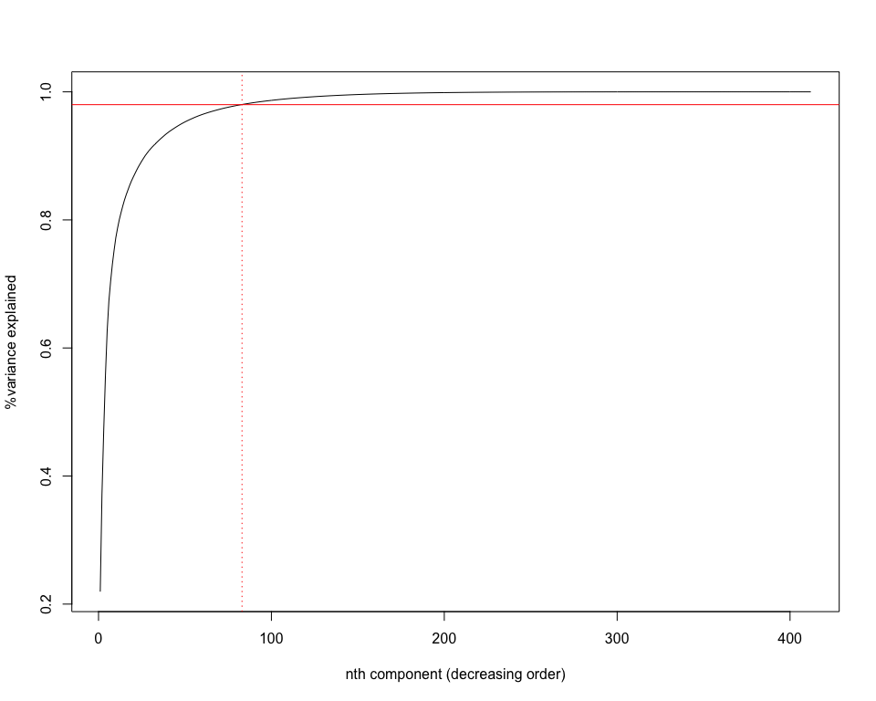

```r
plot(summary(pca.img)$importance[3,], type="l",
     ylab="%variance explained", xlab="nth component (decreasing order)")
abline(h=0.98,col="red");abline(v = vars,col="red",lty=3)
```

برای وضوح بیشتر با highcharter نیز نمودار را کشیده ام:

```r
title = list(text = "Yearly Profit",style = list(color = "white", fontSize="20px"))

sdevs.img %>%
  head(20) %>%
  hchart(type = "spline" , hcaes(x = pc , y = perc_ac), color = 'orange') %>%
  hc_add_series(sdevs.img %>% head(20), "column", hcaes(x = pc, y = perc),name = "Average Score", color = '#EDF69D', borderColor = 'black') %>%
  hc_title(text = 'Picture PCA Analysis',
           align = 'center') %>%
  hc_subtitle(text = 'Top 20 Components', align = 'center') %>%
  hc_xAxis(title = list(text = '#PCA Components')) %>%
  hc_yAxis(title = list(text = 'Cumulative Sum of % of Variance Explained', style = list(fontSize="18px"))) %>%
  hc_add_theme(hc_theme_merge(hc_theme_538(), hc_theme_darkunica()))
```

[interactive chart not shown]

```r
sdevs.img %>%
  hchart(type = 'spline', hcaes(x = pc, y = perc_ac %>% round(5)), color = '#EAF588') %>%
  hc_title(text = 'Picture PCA Analysis',
           align = 'center') %>%
  hc_subtitle(text = 'All Components', align = 'center') %>%
  hc_xAxis(title = list(text = '#PCA Components')) %>%
  hc_yAxis(title = list(text = 'Cumulative Sum of % of Variance Explained', style = list(fontSize="18px"))) %>%
  hc_add_theme(hc_theme_merge(hc_theme_538(), hc_theme_darkunica()))
```

[interactive chart not shown]

برای بدست آوردن حجم عکس ها از دو روش استفاده کرده ام.

در روش اول، تک تک عکس ها را کشیده و ذخیره میکنم و حجم هر یک را بدست می آورم.

```r
sizes1 <- c()
n1 <- sdevs.img %>% nrow()
i <- 5
while(i <= n1){
  chosen.components = 1:i
  feature.vector = pca.img$rotation[,chosen.components]
  feature.vector[1:10,1:5]
  compact.data = t(feature.vector) %*% t(img)
  approx.img = t(feature.vector %*% compact.data)
  png(filename = paste0(i, ".png"))
  image(approx.img, col = grey(seq(0, 1, length = 256)))
  dev.off()
  sizes1[i] <- file.info(paste0(i, ".png"))$size
  i <- i + 10
}

data1 <- as.data.frame(sizes1) %>% select(`Image Size` = sizes1) %>%
  drop_na()
data1$`Number of Principal Components` <- seq(from = 5, to = n1, by = 10)
data1 %>%
  hchart(type = 'column', hcaes(x = `Number of Principal Components`, y = `Image Size`),
         name = "Image Size (Bytes)") %>%
  hc_title(text = 'Image Size Based on Number of Components',
           align = 'center') %>%
  hc_xAxis(title = list(text = '#PCA Components')) %>%
  hc_add_theme(hc_theme_merge(hc_theme_538(), hc_theme_google()))
```

[interactive chart not shown]

این روش، با وجود اینکه تعداد مولفه های انتخابی را ۱۰ تا ۱۰ تا زیاد کرده ام، همچنان زیاد زمان میبرد.

روش بعدی استفاده از `object.size` است.

```r
sizes2 <- c()
n2 <- sdevs.img %>% nrow()
for(i in 5:n2){
  chosen.components = 1:i
  feature.vector = pca.img$rotation[,chosen.components]
  feature.vector[1:10,1:5]
  compact.data = t(feature.vector) %*% t(img)
  approx.img = t(feature.vector %*% compact.data)
  save.size = object.size(compact.data) + object.size(feature.vector)
  sizes2[i - 4] <- save.size
}

data2 <- as.data.frame(sizes2) %>% select(`Image Size` = sizes2)
data2$`Number of Principal Components` <- seq(from = 5, to = n2)
data2 %>%
  hchart(type = 'column', hcaes(x = `Number of Principal Components`, y = `Image Size`),
         name = "Image Size (Bytes)") %>%
  hc_add_theme(hc_theme_merge(hc_theme_538(), hc_theme_google()))
```

[interactive chart not shown]

۱۰. پنج ایده جالبی که روی داده های مالی بالا می توانستیم پیاده کنیم را بیان کنید. (ایده کافی است نیازی به محاسبه بر روی داده نیست.)

- بیشترین میزان نوسانات سهام در یک ماه/شرکت/بخشین
- به دست آوردن رقیبان یک شرکت.
- از لحاظ تاریخی، ۷۵ درصد سهام هم جهت با عموم بازار پیشرفت و یا پسرفت میکند. بررسی صحت این ادعا و همچنین بررسی اینکه آیا این هم جهت بودن به نفع سهام شرکت است یا نه؟
- پیدا کردن پایین ترین قیمت سهام. همچنین پیدا کردن بهترین Comeback، به معنای پیدا کردن بیشترین اختلاف بین افت قیمت و رشد آن.
- دسته بندی کردن شرکت ها به سیاست های اقتصادی مختلفی که استفاده می کنند(شرکت های با سیاست اقتصادی مشابه در یک دسته قرار بگیرند)